# New Reported Events Table Analysis

### Basic Statistics

#### Raw Counts

| Name | Value |
| --- | --- |
| Rows | 6,339,566 |
| Columns | 11 |
| Discrete columns | 7 |
| Continuous columns | 4 |
| All missing columns | 0 |
| Missing observations | 3,946,050 |
| Complete Rows | 2,663,729 |
| Total observations | 69,735,226 |
| Memory allocation | 448.4 Mb |

#### Percentages

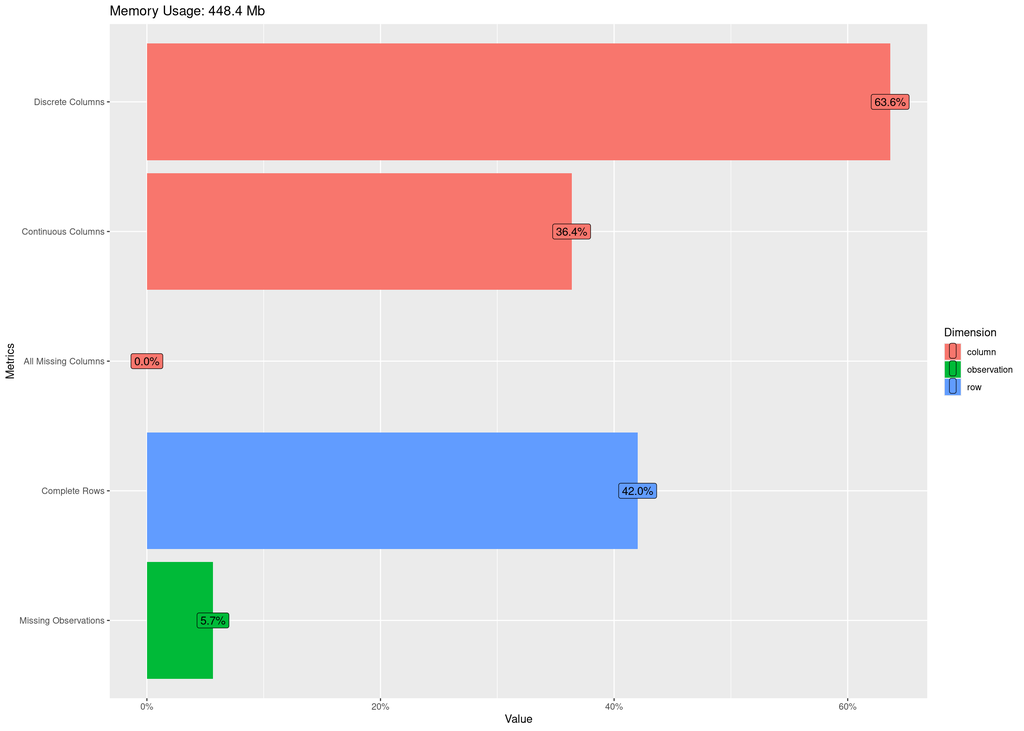

### Data Structure

[interactive chart not shown]

### Missing Data Profile

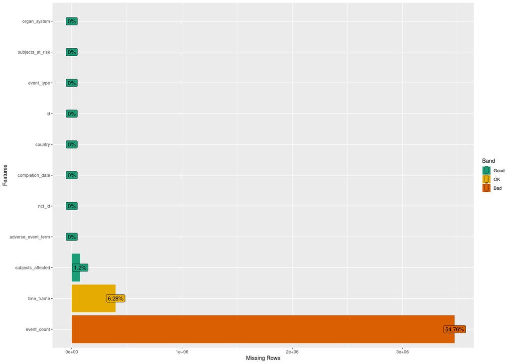

### Univariate Distribution

#### Histogram

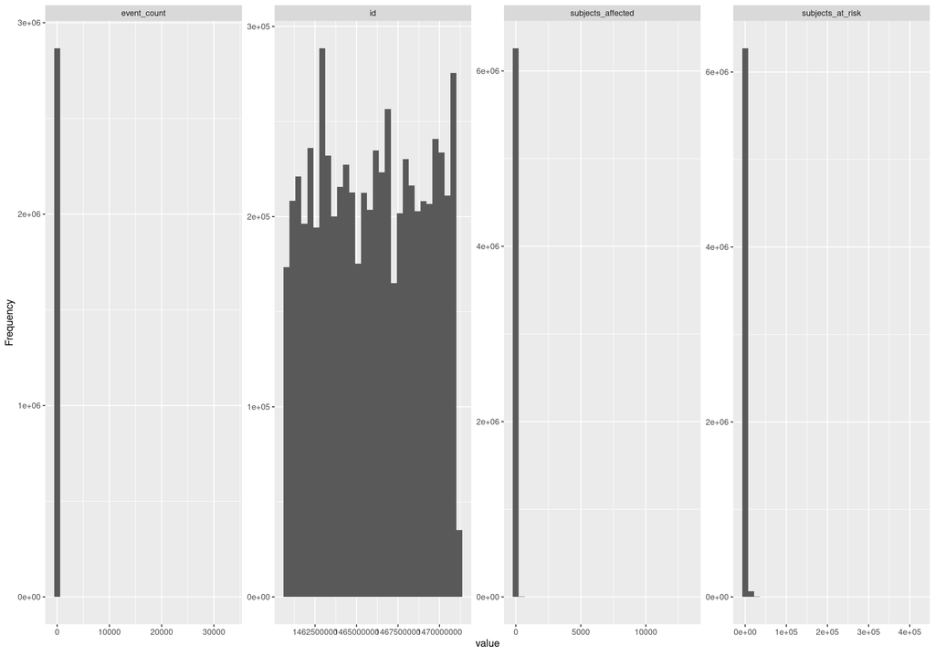

#### Bar Chart (with frequency)

```
## 4 columns ignored with more than 50 categories.
## nct_id: 24886 categories
## completion_date: 3026 categories
## time_frame: 16964 categories
## adverse_event_term: 105829 categories
```

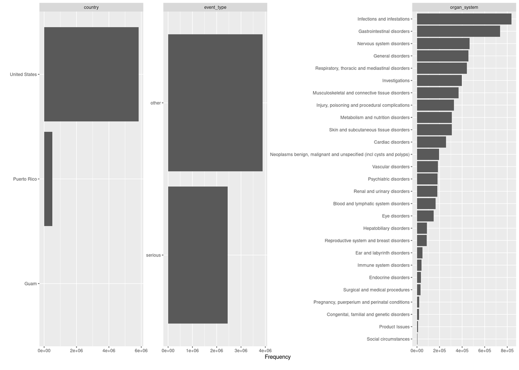